# ¿Desindustrialización global o relocalización geográfica?

Un análisis de la Nueva División Internacional del Trabajo (2000–pospandemia)

Camila Stechina

2026-11-09

# Resumen ejecutivo

El presente informe analiza el fenómeno de la desindustrialización contemporánea y los patrones de especialización comercial entre el año 2000 y la etapa pospandemia. A partir del analísis de la bibliografia de Graña y Terranova (2022), se discute si la pérdida de peso manufacturero observada en diversas economías responde a una evolución natural del capitalismo o a una reorganización geográfica de la producción impulsada por diferenciales salariales.

Para contrastar estas hipótesis de manera empírica, se procesaron datos macroeconómicos y de comercio exterior para una muestra de siete países representativos de distintas inserciones internacionales y con diferentes perfiles en estudio: Alemania (perfil de resistencia industrial), Estados Unidos y Reino Unido (con perfiles de desindustrialización madura), China y Vietnam (sindo polos de reindustrialización) y Argentina y Brasil (con una desindustrialización prematura). A través de tres indicadores: la participación en el PIB industrial mundial, la VCR en productos agroindustriales y la VCR en ramas manufactureras.

# Introducción

Desde la década de 1970, la pérdida de participación del sector manufacturero en el empleo y en el producto total de las economías avanzadas ha despertado un intenso debate académico y político. En las décadas posteriores, esta tendencia también comenzó a registrarse en países de ingresos medios, particularmente en América Latina, dando lugar a diagnósticos sobre una supuesta “desindustrialización prematura”.

El objetivo de este trabajo es abordar esta problemática articulando la discusión conceptual con evidencia empírica reciente. Para ello, el informe se organiza en torno a dos preguntas centrales: **¿Qué explica la desindustrialización de unos y otros países?** y **¿Es correcto afirmar que hubo desindustrialización a nivel mundial?**

Con el fin de responder estos interrogantes, el análisis empírico abarca el período comprendido entre el año 2000 y la salida de la pandemia de COVID-19 (2023), etapa clave de consolidación de las cadenas globales de valor y de ascenso industrial asiático. La selección de siete países permite comparar tres trayectorias estructurales divergentes:

- **Economías desarrolladas tradicionales:** Estados Unidos, Alemania y Reino Unido.
- **Polos industriales de Asia Oriental y Sudoriental:** China y Vietnam, representantes de distintas oleadas de relocalización productiva.
- **Economías sudamericanas:** Argentina y Brasil, casos paradigmáticos de especialización basada en recursos naturales y retroceso manufacturero relativo.

# Desarrollo conceptual

## Crítica a las visiones “mecánica” y “prematura” de la desindustrialización

La literatura económica tradicional suele explicar la desindustrialización como un proceso lineal e inevitable asociado al desarrollo capitalista. En los países ricos, se la presenta como un resultado **mecánico** de la madurez económica, impulsado por dos factores internos: la menor elasticidad-ingreso de la demanda de bienes manufacturados a medida que crece el ingreso per cápita y el mayor ritmo de crecimiento de la productividad industrial frente a los servicios, lo que reduce el empleo relativo en las fábricas.

Por otra parte, cuando la caída industrial ocurre en países en desarrollo a niveles de ingreso per cápita significativamente inferiores, la bibliografía suele calificarla como **desindustrialización prematura** (Rodrik, 2016; Palma, 2013). Desde esta perspectiva, las reformas de apertura comercial y financiera aplicadas desde los años ochenta habrían interrumpido el desarrollo industrial antes de que estas economías alcanzaran los beneficios dinámicos de la manufactura.

Graña y Terranova cuestionan ambos enfoques por asumir implícitamente una trayectoria única de desarrollo nacional. Señalan que el umbral de ingreso per cápita al cual comienza la desindustrialización ha ido cayendo sostenidamente a lo largo del tiempo, lo que vuelve imprecisa la distinción entre procesos “maduros” y “prematuros” y obliga a buscar explicaciones en la dinámica global del capital.

## La Nueva División Internacional del Trabajo y el rol de los costos laborales

Para los autores, la desindustrialización observada desde los años setenta no es un fenómeno natural, sino el resultado de una transformación cualitativa del capitalismo global: el surgimiento de la **Nueva División Internacional del Trabajo (NDIT)**. Dos innovaciones tecnológicas habilitaron este proceso:

1. **La revolución en las telecomunicaciones y el transporte**, que permitió fragmentar los procesos productivos y gestionar cadenas globales de valor a distancia.
2. **La automatización flexible**, que simplificó y estandarizó tareas manufactureras, reduciendo la necesidad de mano de obra altamente calificada en las etapas de ensamblaje y producción básica.

Al eliminarse las barreras técnicas para relocalizar plantas (*offshoring*), la competencia internacional pasó a regirse por los **costos laborales unitarios (CLU)** y, fundamentalmente, por los **salarios medidos al tipo de cambio nominal**. De este modo, las empresas transnacionales trasladaron los segmentos manufactureros más simples hacia regiones con salarios sustancialmente más bajos, generando un proceso en el cual **“unos países desindustrializan a otros”**.

Esta reorganización consolidó una estructura global tripartita:

- **Países desarrollados:** Se desprendieron de la manufactura estandarizada, pero conservaron el control de las cadenas de valor y las actividades intensivas en conocimiento, diseño e investigación y desarrollo.
- **Asia Oriental y Sudoriental:** Se convirtió en el taller industrial del mundo mediante sucesivas “oleadas” de relocalización. Cuando los salarios crecieron en Japón, la producción migró hacia Corea del Sur y Taiwán; posteriormente se desplazó hacia China y Malasia; y, ante el encarecimiento salarial en China durante el siglo XXI, comenzó a trasladarse hacia países de salarios aún menores como **Vietnam** o Bangladesh.
- **América Latina:** Presentaron salarios en dólares más altos y volátiles que los asiáticos, además de menor productividad relativa. Incapaces de competir en manufacturas, quedaron relegadas a su rol histórico como exportadoras de bienes primarios y commodities.

## ¿Desindustrialización mundial o desplazamiento geográfico?

Al agregar el empleo y el valor agregado manufacturero a escala internacional se demuestra que **no existe una desindustrialización a nivel mundial**. La participación global de la industria se ha mantenido relativamente estable durante las últimas cinco décadas (con una variación anual cercana a cero e incluso repuntes impulsados por el crecimiento chino). Lo que a nivel nacional aparece como un declive industrial en Occidente y Sudamérica es, en realidad, la contracara de un **desplazamiento geográfico del centro manufacturero mundial** hacia Asia.

# Metodología

## Construcción de indicadores

# Resultados y análisis

## La relocalización de la producción manufacturera mundial

El análisis de la evolución del PBI industrial mundial entre 2000 y la etapa pospandemia confirma de manera contundente la relocalización geográfica frente a la idea de una desindustrialización global.

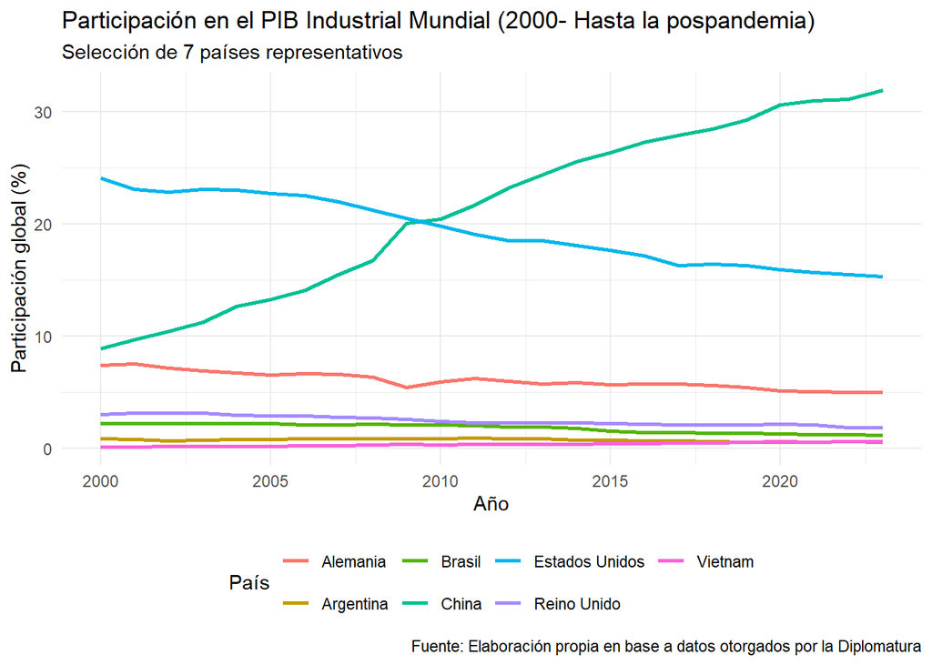

Como se observa, las economías desarrolladas experimentaron un retroceso sostenido en su peso relativo dentro de la manufactura global. Estados Unidos, que en el año 2000 concentraba cerca del 24 % del producto industrial mundial, descendió de manera continua hasta ubicarse alrededor del 15 % tras la pandemia. Alemania mostró una trayectoria más resiliente, aunque también registró una reducción moderada (pasando de aproximadamente 7,5 % a 5 %), mientras que el Reino Unido mantuvo una participación marginal inferior al 3 % en todo el período.

Este retroceso occidental encuentra su contracara exacta en el ascenso de China. Partiendo de una cuota cercana al 9 % en 2000, la economía china triplicó su participación hasta superar el 30 % del PIB industrial mundial, desplazando a Estados Unidos como principal potencia manufacturera hacia 2009–2010.

Por su parte, Argentina y Brasil mantuvieron participaciones bajas y estancadas (en torno al 1 %–2 %), evidenciando su incapacidad para ganar terreno en la producción industrial global, mientras que Vietnam comienza a mostrar una trayectoria ascendente desde niveles iniciales muy bajos.

## La especialización agroindustrial de América del Sur

El cálculo de la Ventaja Comparativa Revelada en sectores agroindustriales y forestales permite observar el modo en que las economías sudamericanas se insertaron en la Nueva División Internacional del Trabajo.

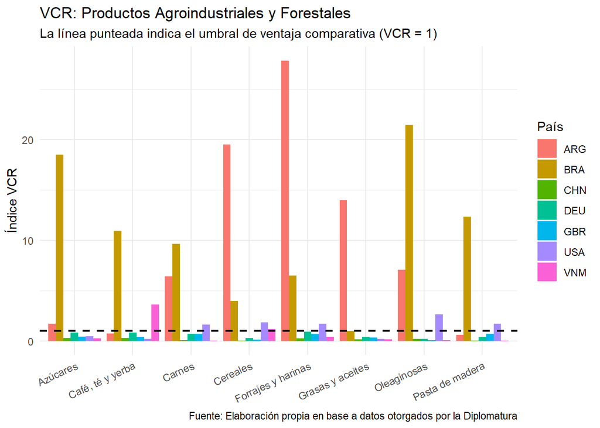

Los resultados exhiben una marcada polarización entre bloques regionales. Argentina y Brasil presentan índices de VCR extraordinariamente elevados por encima del umbral de especialización:

• Argentina lidera con amplia diferencia en forrajes y harinas, cereales, grasas y aceites, además de registrar ventajas sólidas en oleaginosas y carnes.

## La división del trabajo dentro de las manufacturas y las oleadas asiáticas

Finalmente, la desagregación del índice VCR en siete ramas industriales revela la jerarquía interna de la producción manufacturera contemporánea y la dinámica de las “oleadas” asiáticas.

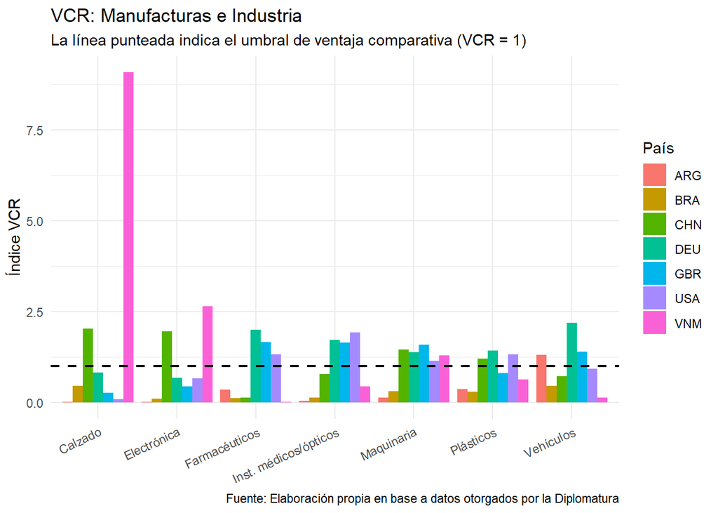

## Síntesis de resultados

La evidencia empírica confirma que el capitalismo contemporáneo no atraviesa una desindustrialización global, sino una profunda reconfiguración geográfica y sectorial.

Los resultados confirman que existe un desplazamiento del centro manufacturero hacia Oriente.

Mientras Asia absorbe el grueso de la manufactura mundial mediante sucesivas oleadas de relocalización salarial y las potencias tradicionales retienen los eslabones de mayor intensidad tecnológica, América del Sur enfrenta una desindustrialización relativa que refuerza su dependencia de las exportaciones primarias.

# Referencias